# Analysis of in vivo Isotope Labeled Duckweed

Raven L B Johnson

2025-02-28

# Contents

## 1 Unlabeled Duckweed Analysis

Normalization and processing is important for consistent MSIi analysis. Here, we import the imzML file and perform TIC normalization and peak binning. We sum to intensities in the pixels to create a TIC image and average the intensities for each m/z value to produce an average mass spectrum for the entire MSI dataset.

```r
# import
cntrl <- readMSIData("0A.imzML")

# normalize and bin at 3 mDa
cntrl_normAlign <- cntrl |>
  normalize(method="tic") |>
  peakProcess(tolerance=0.003, units="mz")

# calculate TIC and mean spectrum
cntrl_normAlign <- cntrl_normAlign |>
  summarizePixels(c(TIC="sum")) |>
  summarizeFeatures(c(Mean = "mean"))
```

Below we plot the TIC and mean spectrum.

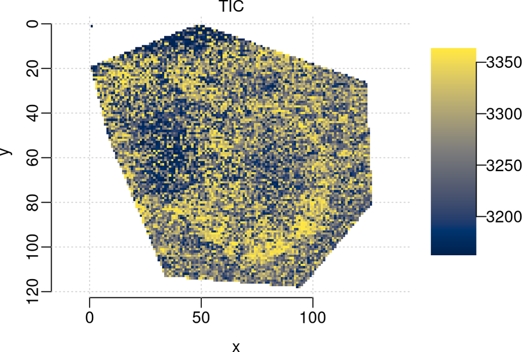

```r
image(cntrl_normAlign,"TIC", col=matter::cpal("Cividis"), enhance="hist")
```

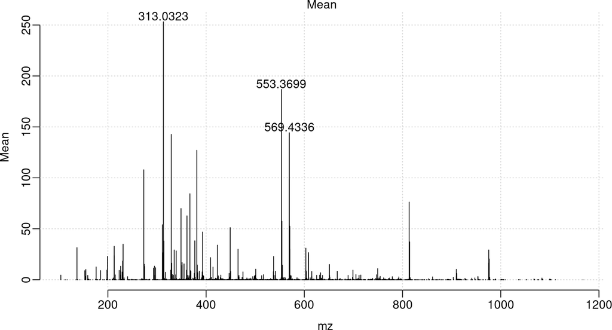

```r
plot(cntrl_normAlign, "Mean", annPeaks=3)
```

We can perform spatial shrunken centroid segmentation on the unlabeled duckweed imaging dataset.

```r
cntrl_nobkgrem <- spatialShrunkenCentroids(cntrl_normAlign,
                                           r = 1, s=2^(1:5), k = 5,
                                           weights = "gaussian")
```

```r
cntrl_nobkgrem
```

```
## ResultsList of length 5
## names(5): r=1,k=5,s=2 r=1,k=5,s=4 r=1,k=5,s=8 r=1,k=5,s=16 r=1,k=5,s=32
## model: SpatialShrunkenCentroids
##              r k  s  weights clusters sparsity      AIC      BIC
## r=1,k=5,s=2  1 5  2 gaussian        5     0.65 9643.870 45172.38
## r=1,k=5,s=4  1 5  4 gaussian        5     0.76 7653.988 35821.07
## r=1,k=5,s=8  1 5  8 gaussian        5     0.85 6111.228 28550.29
## r=1,k=5,s=16 1 5 16 gaussian        5     0.92 4977.283 23218.26
## r=1,k=5,s=32 1 5 32 gaussian        5     0.96 4215.248 19655.03
```

It is important to note that while SSC segmentation is able to pick out the tissue from the tape, segmentation of the tape background is also being performed. Therefore, we want to remove the tape background from further consideration.

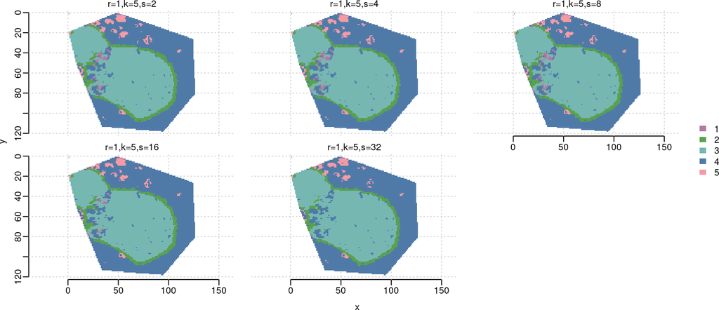

```r
image(cntrl_nobkgrem, i=1:5,select=c(5,3,2,1,4),col=c("#B07AA1","#59A14E","#76B7B2","#4F7AA8","#F59AA5"))
```

To remove the tape background, we use SSC segmentation to find the background and the tissue regions where k = 2.

```r
cntrl_bkgdrem <- spatialShrunkenCentroids(cntrl_normAlign,
                                          r = 3, s=16,k=2, weights = "gaussian")
cntrl_normAlign$regions <- makeFactor(
  tissue = (cntrl_bkgdrem@model[["class"]]==1),
  bkgd = (cntrl_bkgdrem@model[["class"]]==2))
```

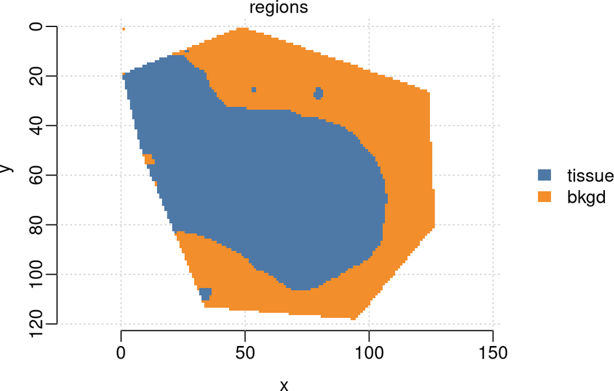

```r
image(cntrl_normAlign, "regions")
```

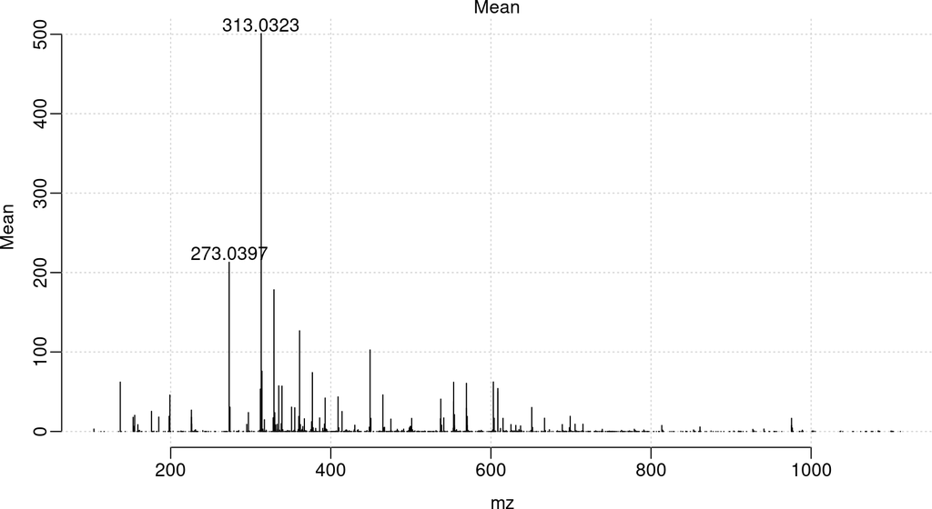

```r
# subset the background pixels
cntrl_bkgd <- subsetPixels(cntrl_normAlign, regions=="bkgd")

# calculate the TIC and mean spectrum
cntrl_bkgd <- cntrl_bkgd |>
  summarizePixels(c(TIC="sum")) |>
  summarizeFeatures(c(Mean = "mean"))
plot(cntrl_bkgd, "Mean", annPeaks=2)
```

We do the same for the tissue segment.

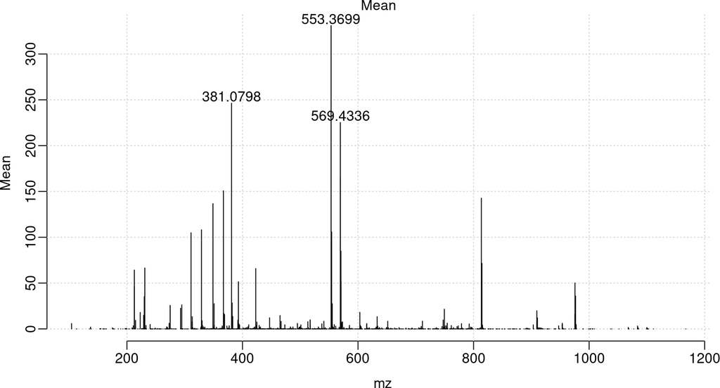

```r
# subset the non-background pixels
cntrl_tissue <- subsetPixels(cntrl_normAlign, regions!="bkgd")

# calculate the TIC and mean spectrum for the non-background pixels
cntrl_tissue <-cntrl_tissue |>
  summarizePixels(c(TIC="sum")) |>
  summarizeFeatures(c(Mean = "mean"))

plot(cntrl_tissue, "Mean", annPeaks=3)
```

```r
# SSC segmentation of tissue-only region
cntrl_ssc_tissue <- spatialShrunkenCentroids(cntrl_tissue, r=1, s= 2^(1:5),k=4,
                                            weights = "adaptive")
```

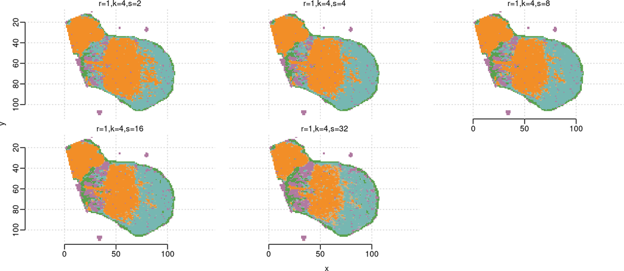

```r
# plot all models
image(cntrl_ssc_tissue, i=1:5, key=FALSE, select=c(3,4,2,1),
      col=c("#B07AA1","#F28E27","#59A14E","#76B7B2"))
```

We select the model with s = 8 as an example.

```r
# select s = 8 model
cntrl_ssc_tissue_Mdl3 <- cntrl_ssc_tissue[[3]]
```

The t-statistics for this model show distinct differences in feature intensity across the four segments.

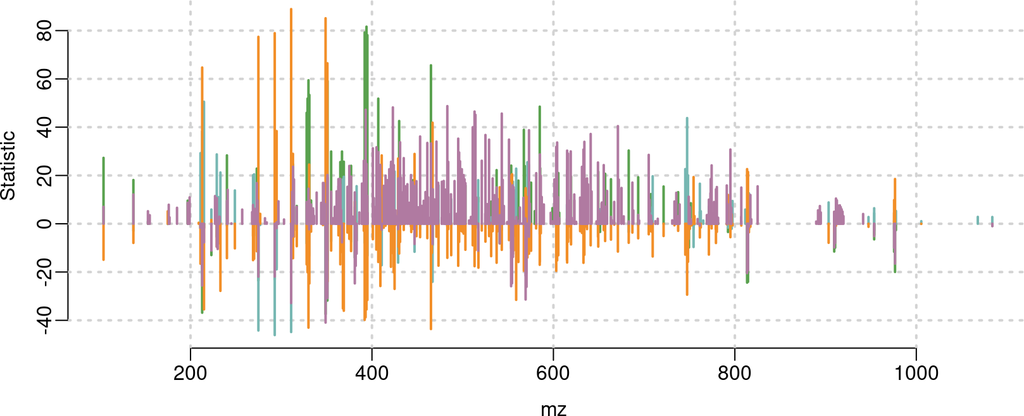

```r
# t-statistics
plot(cntrl_ssc_tissue_Mdl3, type="statistic", key=FALSE,
     scale=TRUE, lwd=2,select = c(3,4,2,1),
     col=c("#B07AA1","#F28E27","#59A14E","#76B7B2"))
```

The shrunken centroids allow for a comparison of scaled mean mass spectra from each segment for a more direct comparison of the differences in analyte intensities.

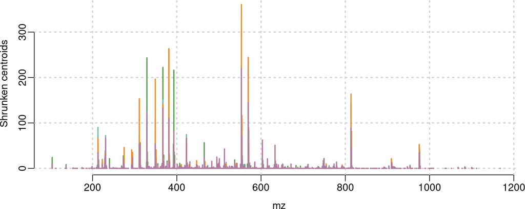

```r
# shrunken centroids
plot(cntrl_ssc_tissue_Mdl3, type="centers", key=FALSE,
     scale=TRUE, lwd=2,select = c(3,4,2,1),
     col=c("#B07AA1","#F28E27","#59A14E","#76B7B2"))
```

We are then able to define the regions and plot them with annotations.

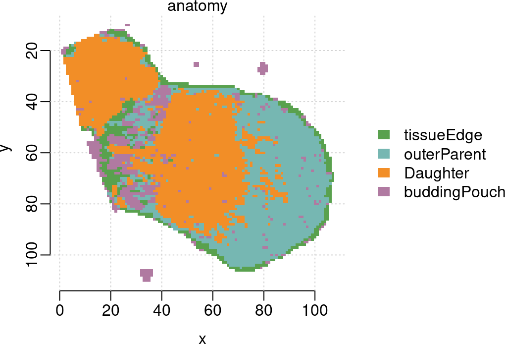

```r
# create a factor for each segment
cntrl_tissue$anatomy <- makeFactor(
  tissueEdge = (cntrl_ssc_tissue_Mdl3@model[["class"]] == 3),
  outerParent = (cntrl_ssc_tissue_Mdl3@model[["class"]] == 4),
  Daughter = (cntrl_ssc_tissue_Mdl3@model[["class"]] == 2),
  buddingPouch = (cntrl_ssc_tissue_Mdl3@model[["class"]] == 1))

# plot the segments
image(cntrl_tissue, "anatomy",
      col=c("#59A14E","#76B7B2","#F28E27","#B07AA1"))
```

Here, we extract the ranked t-statistics from the s = 8 model and plot a specific m/z value to represent each region.

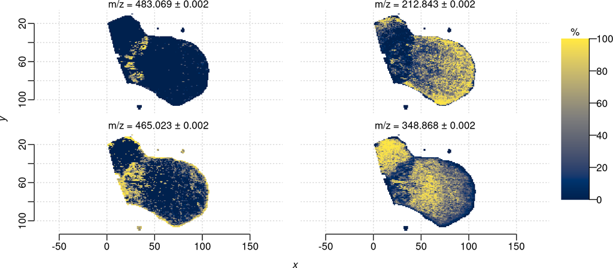

```r
# subset the top features from the model
cntrl_top <- topFeatures(cntrl_ssc_tissue_Mdl3)

# plot one ion image for each segment
image(cntrl_tissue, mz=c(483.069,212.843, 465.023,348.868),
      tolerance=0.002, units="mz", enhance="hist",scale=TRUE,
      col=matter::cpal("Cividis"))
```

We also demonstrate the the localizations of potassium phospate and DHB with potassium phosphate are the same.

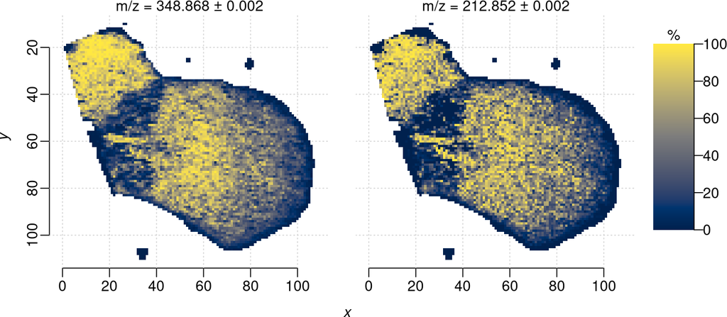

```r
image(cntrl_tissue, mz=c(348.868, 212.852),
      tolerance=0.002, units="mz", enhance="hist",scale=TRUE,
      col=matter::cpal("Cividis"))
```

## 2 Two-Day 13C-Labeled Duckweed

As with the unlabeled duckweed sample, the two-day 13-carbon duckweed was TIC normalized and processed Below, we plot average mass spectrum for the entire MSI dataset.

```r
twoA <- readMSIData("2dayA_13C_Realigned.imzML")
centroided(twoA) <- FALSE

twoA_normAlign <- twoA |>
  normalize(method="tic") |>
  peakProcess(tolerance=0.002, units="mz")
twoA_normAlign <- twoA_normAlign |>
  summarizePixels(c(TIC="sum")) |>
  summarizeFeatures(c(Mean = "mean"))
```

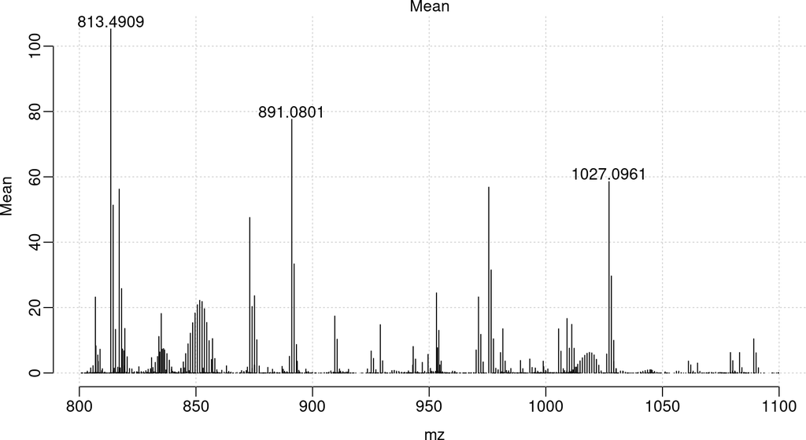

```r
plot(twoA_normAlign, "Mean", annPeaks=3)
```

SSC segmentation was used to find the tape and tissue related pixels.

```r
twoA_bkgdrem <- spatialShrunkenCentroids(twoA_normAlign, r = 3, s=0,k=3,
                                         weights = "gaussian")
twoA_normAlign$regions <- makeFactor(
  tissue = (twoA_bkgdrem@model[["class"]]!=3),
  bkgd = (twoA_bkgdrem@model[["class"]]==3))
```

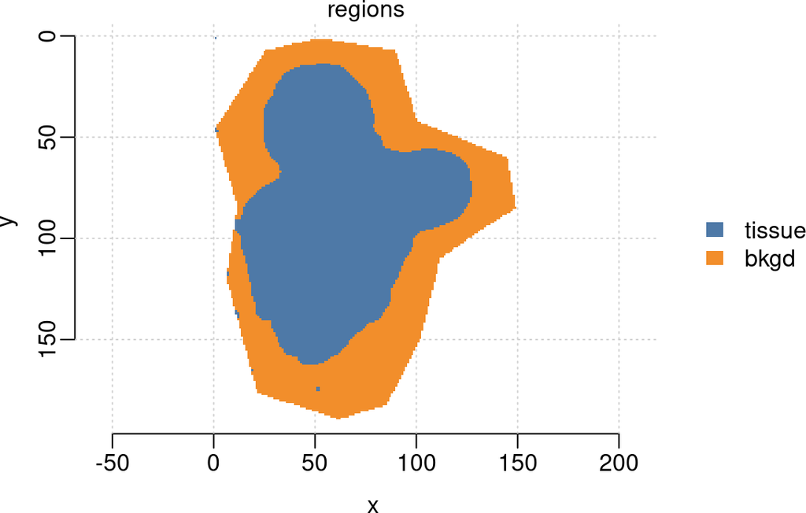

```r
image(twoA_normAlign, "regions")
```

Below, the average mass spectrum for the background is shown.

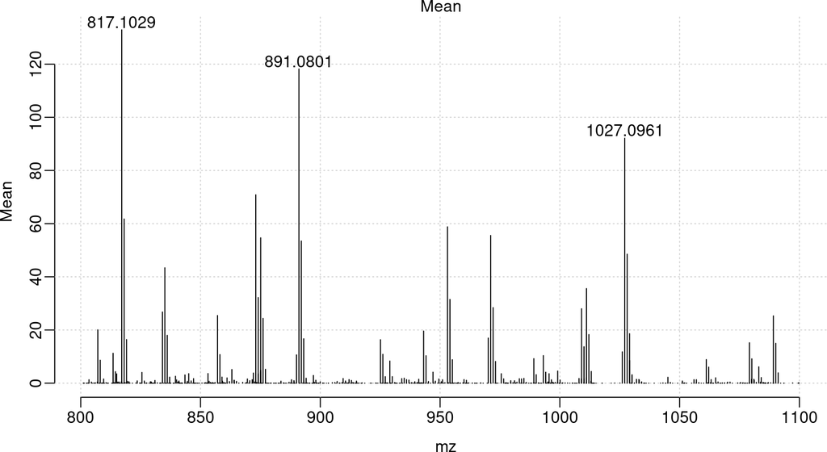

```r
twoA_bkgd <- subsetPixels(twoA_normAlign, regions=="bkgd")
twoA_bkgd <- twoA_bkgd |>
  summarizePixels(c(TIC="sum")) |>
  summarizeFeatures(c(Mean = "mean"))

plot(twoA_bkgd, "Mean", annPeaks=3)
```

We also plot the average mass spectrum of the tissue region. Here, isotope labeling can be observed more readily than in the combined average.

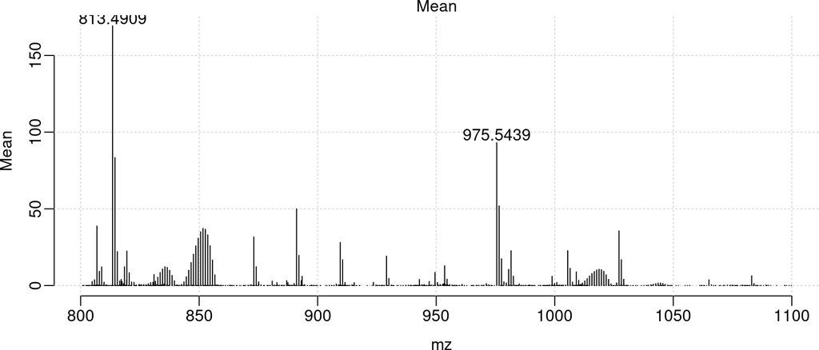

```r
twoA_tissue <- subsetPixels(twoA_normAlign, regions!="bkgd")
twoA_tissue <- twoA_tissue |>
  summarizePixels(c(TIC="sum")) |>
  summarizeFeatures(c(Mean = "mean"))

plot(twoA_tissue, "Mean", annPeaks=2)
```

Segmentation of the tissue region.

```r
twoA_ssc_tissue <- spatialShrunkenCentroids(twoA_tissue, r = 1, s= 2^(0:5),k=4,
                                            weights = "gaussian")
```

```r
twoA_ssc_tissue
```

```
## ResultsList of length 6
## names(6): r=1,k=4,s=1 r=1,k=4,s=2 r=1,k=4,s=4 r=1,k=4,s=8 r=1,k=4,s=16 r=1,k=4,s=32
## model: SpatialShrunkenCentroids
##              r k  s  weights clusters sparsity      AIC      BIC
## r=1,k=4,s=1  1 4  1 gaussian        4     0.62 6297.084 29215.63
## r=1,k=4,s=2  1 4  2 gaussian        4     0.74 5143.928 23788.28
## r=1,k=4,s=4  1 4  4 gaussian        4     0.82 4316.371 19931.93
## r=1,k=4,s=8  1 4  8 gaussian        4     0.88 3747.546 17211.27
## r=1,k=4,s=16 1 4 16 gaussian        4     0.93 3274.452 14969.54
## r=1,k=4,s=32 1 4 32 gaussian        4     0.96 3030.039 13612.37
```

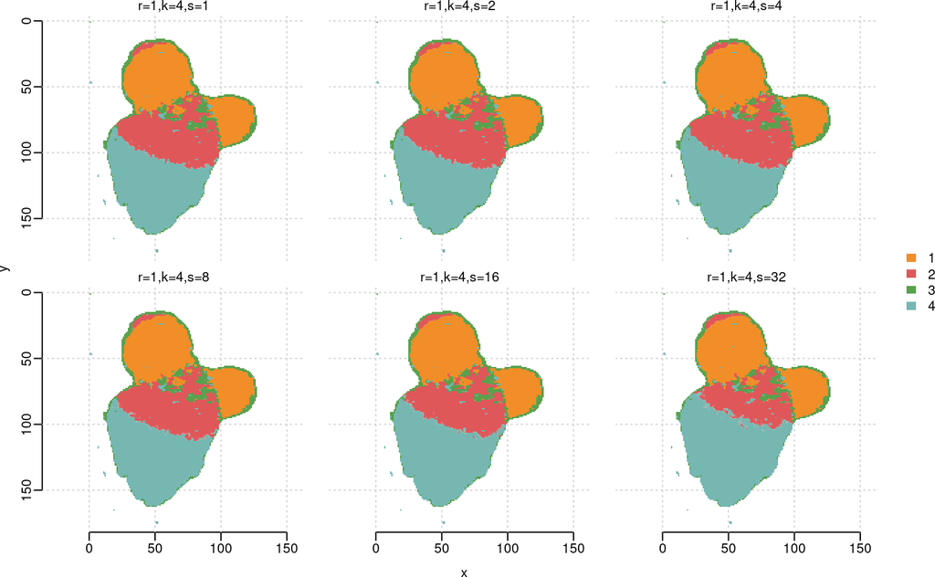

```r
image(twoA_ssc_tissue, i=1:6, col = c("#F28E27","#E05759","#59A14E","#76B7B2"))
```

Select model with s = 8 for consistency and plot the t-statistics.

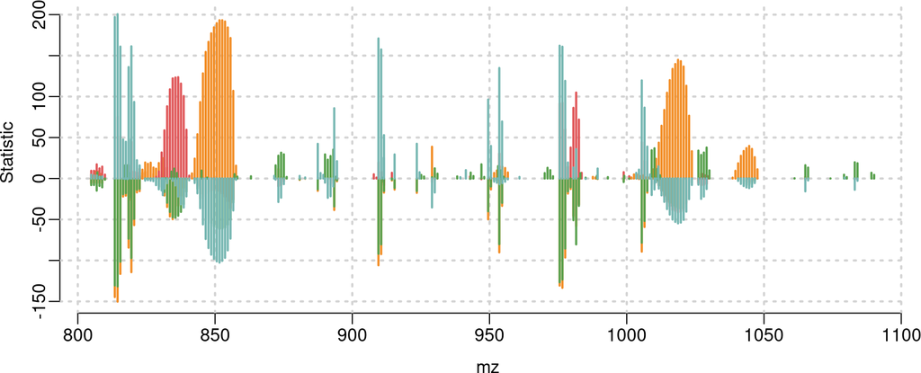

```r
twoA_ssc_tissue_Mdl4 <- twoA_ssc_tissue[[4]]

plot(twoA_ssc_tissue_Mdl4, type="statistic", key=FALSE, scale=TRUE,
     lwd=2, col = c("#F28E27","#E05759","#59A14E","#76B7B2"))
```

Here, we plot the shrunken centroids.

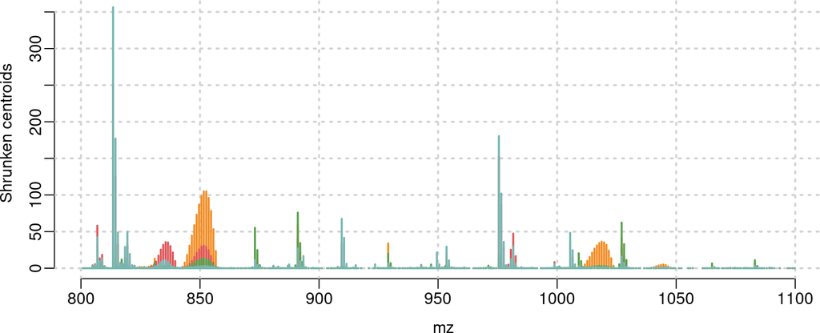

```r
plot(twoA_ssc_tissue_Mdl4, type="centers", key=FALSE, scale=TRUE,
     lwd=2, col = c("#F28E27","#E05759","#59A14E","#76B7B2"))
```

We are able to define and annotate each segment.

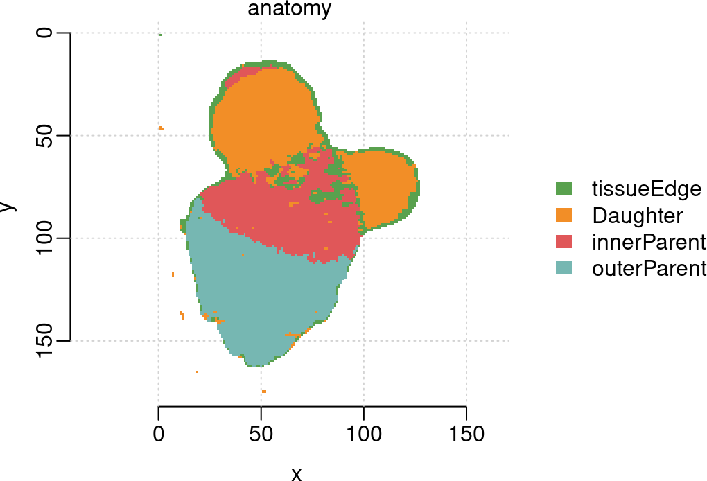

```r
twoA_top <- topFeatures(twoA_ssc_tissue_Mdl4)
twoA_tissue$anatomy <- makeFactor(
  tissueEdge = (twoA_ssc_tissue_Mdl4@model[["class"]] == 3),
  Daughter = (twoA_ssc_tissue_Mdl4@model[["class"]] == 1),
  innerParent = (twoA_ssc_tissue_Mdl4@model[["class"]] == 2),
  outerParent = twoA_ssc_tissue_Mdl4@model[["class"]] == 4)
image(twoA_tissue, "anatomy",
      col=c("#59A14E","#F28E27","#E05759","#76B7B2"))
```

## 3 Three-Day 13C-Labeled Duckweed

Three-day 13-carbon duckweed was TIC normalized and processed Below, we plot average mass spectrum for the entire MSI dataset.

```r
threeC <-readMSIData("3dayC_13C_Realigned.imzML")
centroided(threeC) <- FALSE

threeC_normAlign <- threeC |>
  normalize(method="tic") |> #TIC Normalization
  peakProcess(tolerance=0.002, units="mz")

threeC_normAlign<- threeC_normAlign |>
  summarizePixels(c(TIC="sum")) |>
  summarizeFeatures(c(Mean = "mean"))
```

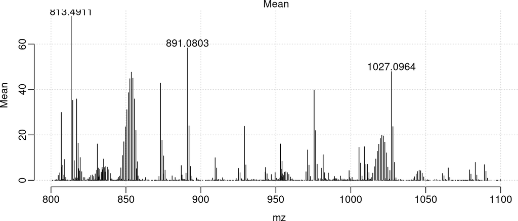

```r
plot(threeC_normAlign, "Mean", annPeaks=3)
```

We use SSC to segment the background and the tissue regions, assign each region an annotation, then plot the regions of the MSI dataset.

```r
threeC_bkgdrem <- spatialShrunkenCentroids(threeC_normAlign, r = 2, s= 8,k=3,
                                           weights = "gaussian")

threeC_normAlign$regions <- makeFactor(
  tissue = (threeC_bkgdrem@model[["class"]]!=1),
  bkgd = (threeC_bkgdrem@model[["class"]]==1))
```

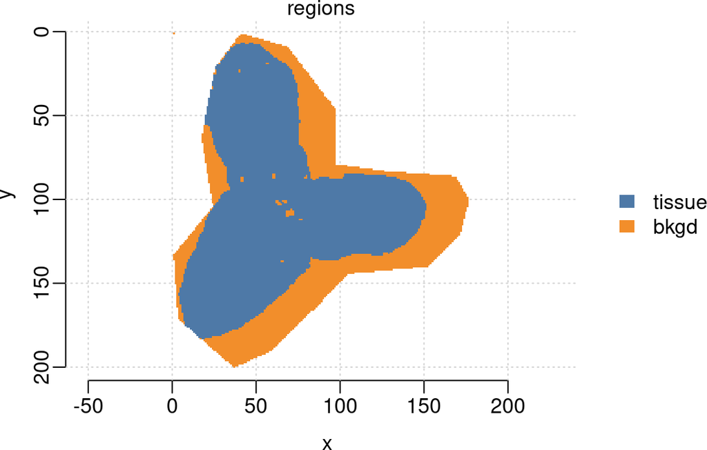

```r
image(threeC_normAlign, "regions")
```

Subset the the background and, below, plot the average mass spectrum of the tape region.

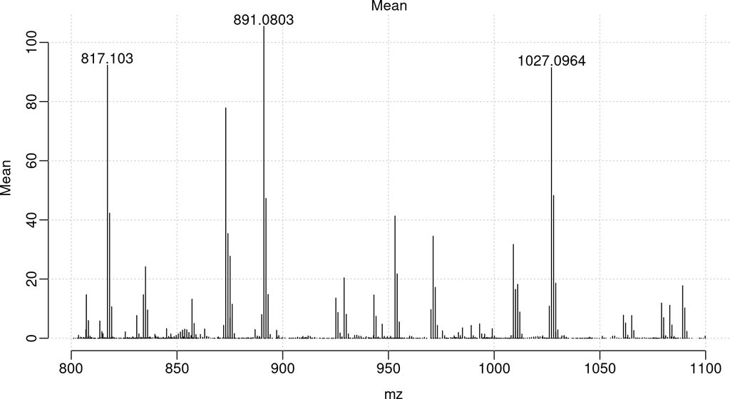

```r
threeC_bkgd <- subsetPixels(threeC_normAlign, regions == "bkgd")

threeC_bkgd <- threeC_bkgd |>
  summarizePixels(c(TIC="sum")) |>
  summarizeFeatures(c(Mean = "mean"))

plot(threeC_bkgd, "Mean", annPeaks=3)
```

Subset and plot the average mass spectrum for the tissue region

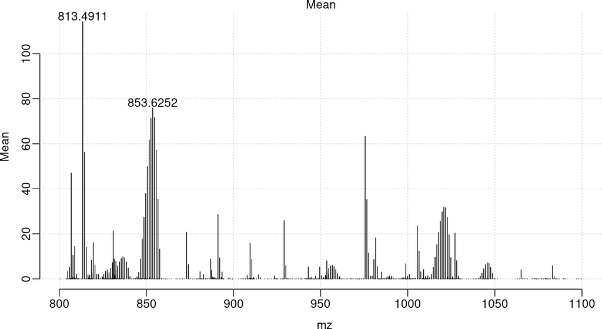

```r
threeC_tissue <- subsetPixels(threeC_normAlign, regions == "tissue")

threeC_tissue <- threeC_tissue |>
  summarizePixels(c(TIC="sum")) |>
  summarizeFeatures(c(Mean = "mean"))

plot(threeC_tissue, "Mean", annPeaks=2)
```

Perform SSC segmentation on the three-day 13-carbon labeled duckweed sample.

```r
threeC_ssc_tissue <- spatialShrunkenCentroids(threeC_tissue,
                                              r=2, k = 5, s= 2^(0:5),
                                              weights="gaussian")
```

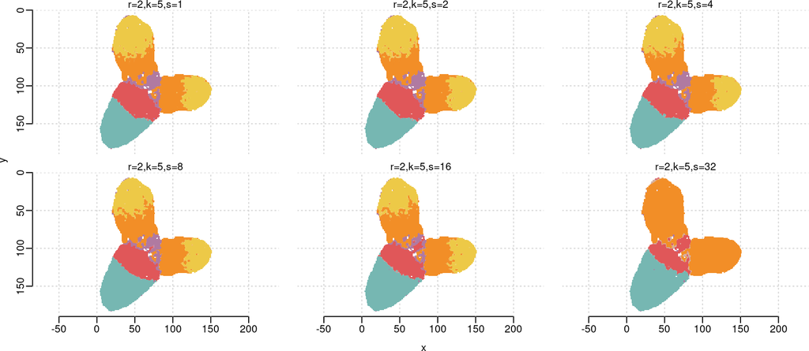

```r
image(threeC_ssc_tissue, i = 1:6, key=FALSE,
      col = c("#E05759","#76B7B2","#F28E27","#EDC947","#B07AA1"))
```

We select the model with s = 8 as an example and plot the t-statistics.

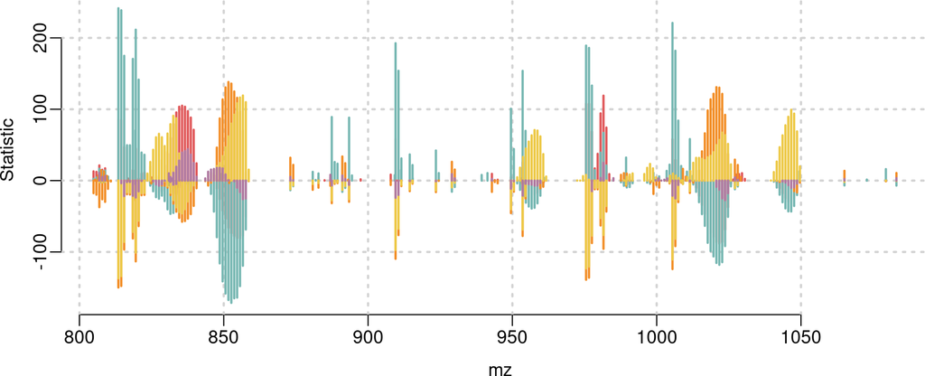

```r
threeC_ssc_tissue_Mdl4 <- threeC_ssc_tissue[[4]]
plot(threeC_ssc_tissue_Mdl4, type = "statistic", lwd = 2, key=FALSE,
     col = c("#E05759","#76B7B2","#F28E27","#EDC947","#B07AA1"))
```

Then we show the shrunken centroids.

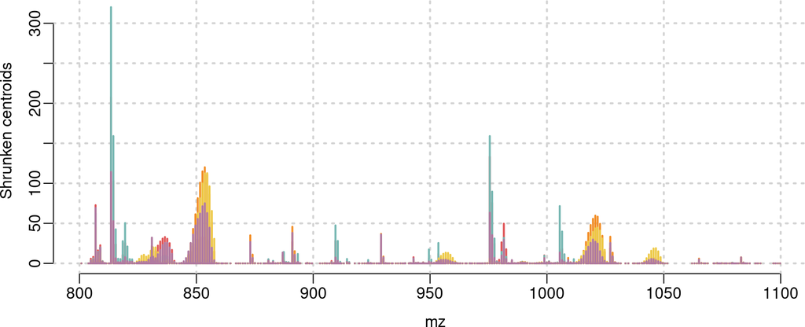

```r
plot(threeC_ssc_tissue_Mdl4, type = "centers", lwd = 2, scale = TRUE, key=FALSE,
     col = c("#E05759","#76B7B2","#F28E27","#EDC947","#B07AA1"))
```

We are able to extract the ranked t-statistics from this model and annotate the regions of the plant.

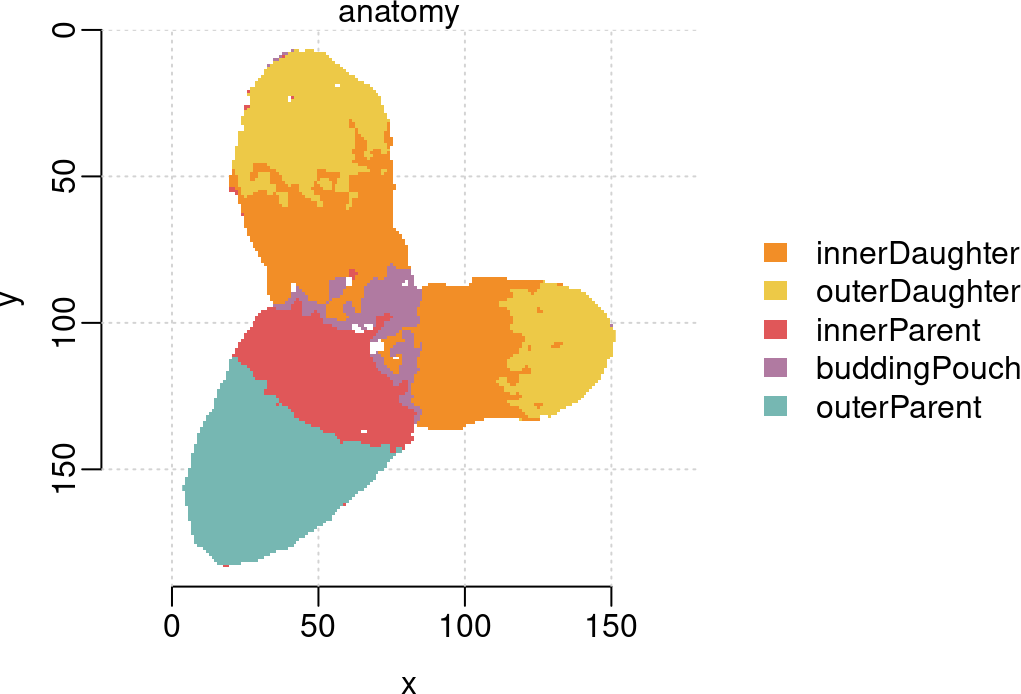

```r
threeC_top <- topFeatures(threeC_ssc_tissue_Mdl4)

threeC_tissue$anatomy <- makeFactor(
  innerDaughter = (threeC_ssc_tissue_Mdl4@model[["class"]] == 3),
  outerDaughter = (threeC_ssc_tissue_Mdl4@model[["class"]] == 4),
  innerParent = (threeC_ssc_tissue_Mdl4@model[["class"]] == 1),
  buddingPouch = (threeC_ssc_tissue_Mdl4@model[["class"]] == 5),
  outerParent = threeC_ssc_tissue_Mdl4@model[["class"]] == 2)
image(threeC_tissue, "anatomy",
      col=c("#F28E27","#EDC947","#E05759","#B07AA1","#76B7B2"))
```

## 4 Five-Day D-Labeled Duckweed

Here, we break down the analysis of deuterium labeled duckweed samples into two parts: the lipid mass range and the whole mass range. We start by normalizing the data and binning with a mass tolerance of 2 mDa. We turn off peak filtering to ensure that even the low intensity peaks are preserved.

```r
fiveB <-readMSIData("5dayB_2H.imzML")

fiveB_normAlign<- fiveB|>
  normalize(method="tic") |> #TIC Normalization
  peakProcess(tolerance=0.002, units="mz", filterFreq = 0)

fiveB_normAlign <- fiveB_normAlign |>
  summarizePixels(c(TIC="sum")) |>
  summarizeFeatures(c(Mean = "mean"))
```

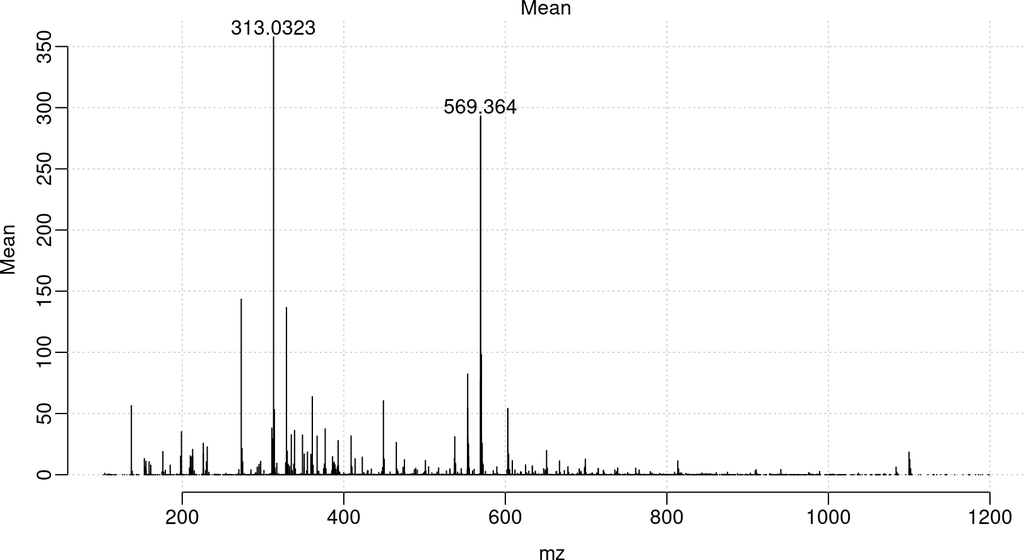

```r
plot(fiveB_normAlign, "Mean", annPeaks = 2)
```

Below, the TIC image of the deuterium labeled sample.

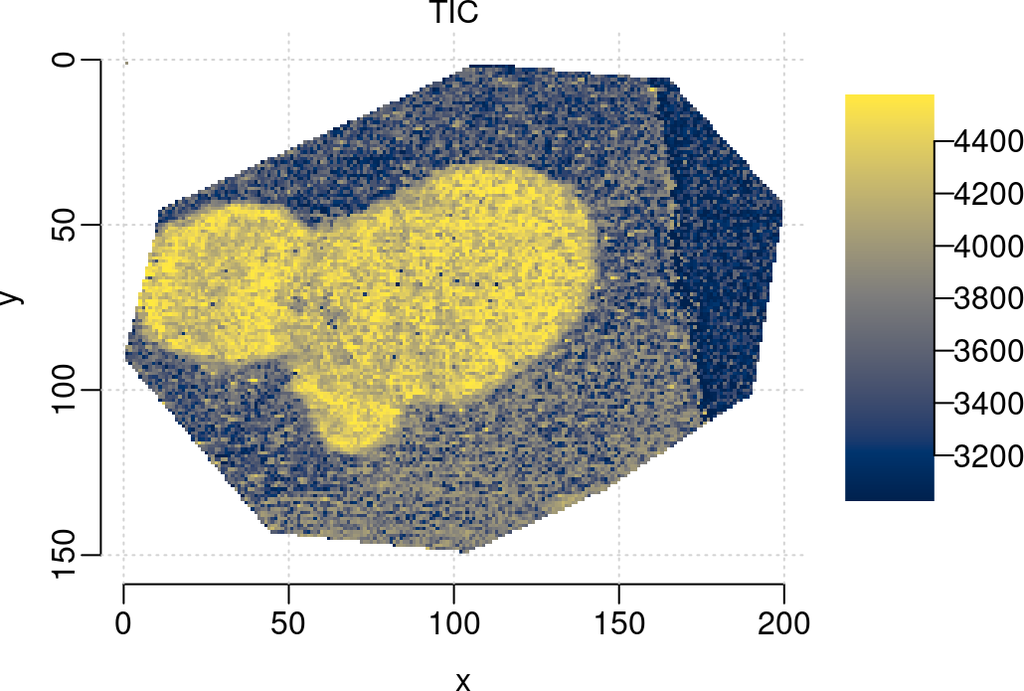

```r
image(fiveB_normAlign, "TIC", enhance="hist", col=matter::cpal("Cividis"))
```